# 0930Report–Codebook and Explorartory Analysis

Boyang Zhang

### Data Description

The data used in this research is obtained from the Fatality Analysis Reporting System of the National Highway Traffic Safety Administration, focused on the Maryland and Washington, DC area from years 2011 to 2015.

```r
####2011-2015 trend accident
#merge data from 2011-2015
acc1=filter_dat(file.path(paste0(data_path,"2011"),"accident.sas7bdat"))
acc2=filter_dat(file.path(paste0(data_path,"2012"),"accident.sas7bdat"))
acc3=filter_dat(file.path(paste0(data_path,"2013"),"accident.sas7bdat"))
acc4=filter_dat(file.path(paste0(data_path,"2014"),"accident.sas7bdat"))
acc5=filter_dat(file.path(paste0(data_path,"2015"),"accident.sas7bdat"))

acc_tmp=subset(rbind(acc1,acc2,acc3,acc4),select = -`road_fnc`)
acc5=subset(acc5,select = -c(`func_sys`,`rd_owner`,`rur_urb`))
acc=rbind(acc_tmp,acc5)

acc$typ_int=ifelse(acc$typ_int==98 |acc$typ_int==99,NA,acc$typ_int)
```

#### Accident file(2011-2015):

Among 2336 accidents and 2524 fatalities, several crash-level related factors are listed as follows.

**1. Time-varying variables**

**2. Geographical factors**

- Intersection type: most of the accidents do not occur in intersection area and remaining accidents are mostly occurred in four-way intersection and T intersection.
- National highway system: among all accidents, a quarter of accidents are in NHS.
- Trafficway: identify specific roads

**3. Enviornmental factors**

- Light condition: indicate type/level of light that existed at the time of the crash( day or night).
- Weather: summary of weather condition. Most of the accidents do not occur during adverse weather conditions.

**4. Information about crash**

- Number of persons not in vehicles in transport: most of the accidents do not involve other person outside transporting vehicle, but still a quarter involves other people outside the car.
- Number of persons in transporting vehicle ranging from 1 to 18.
- First harmful events(accidents): first cause of crash and the top five harmful events are namely, vehicle in transport, pedestrian, tree, curb and guardrail face.
- Crash related factors: This contain too much missingness. Similar information can also be obtained from vehicle files and person files (vehicle-level related factors, driver-level related factors and person-level related factors in the Person data file).
- Drunk drivers: roughly a quarter involves drunk driving.

**Explorartory analysis**

**Time varying factors**

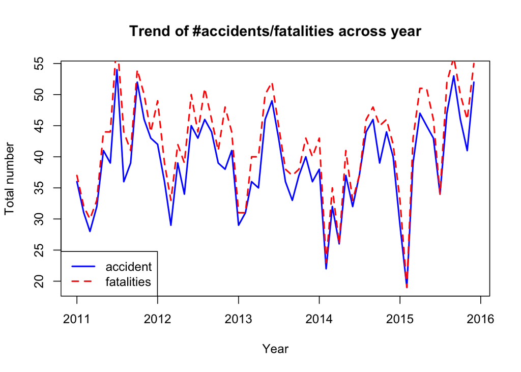

```r
#exploratory analysis: time-varying
acc_month_sum=acc %>% group_by(year,month) %>%
    summarize(total=n(),fatal=sum(fatals)) %>%
    mutate(ym=as.Date(as.yearmon(paste(year,month,sep="/"),"%Y/%m")))


plot(acc_month_sum$ym,acc_month_sum$total,type="l",col="blue",lwd=2,xlab="Year",ylab="Total number",main="Trend of #accidents/fatalities across year")
lines(acc_month_sum$ym,acc_month_sum$fatal,col="red",lty=2,lwd=2)
legend("bottomleft",legend=c("accident","fatalities"),col=c("blue","red"),lwd=rep(2,2),lty=1:2)
```

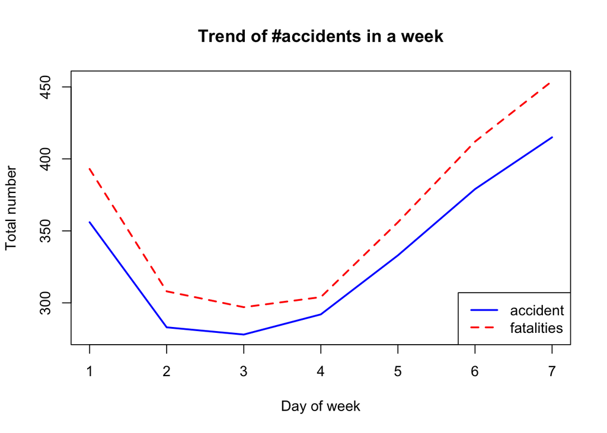

```r
acc_day_sum=acc %>% group_by(day_week) %>%
    summarize(total=n(),fatal=sum(fatals))
with(acc_day_sum,plot(day_week,total,type="n",xlab="Day of week",ylab="Total number",main="Trend of #accidents in a week",ylim=c(range(total)[1],range(fatal)[2])))

# for(i in 1:length(unique(acc_day_sum$year))){
#     k=2010+i
#     with(acc_day_sum,lines(day_week[which(year==k)],total[which(year==k)],col=i,lwd=2))
# }

with(acc_day_sum,lines(day_week,total,col="blue",lwd=2))
with(acc_day_sum,lines(day_week,fatal,col="red",lwd=2,lty=2))
legend("bottomright",legend=c("accident","fatalities"),col=c("blue","red"),lwd=rep(2,2),lty=1:2)
```

**Geographical factors**

[figure not shown]

```r
#exploratory analysis: Geographical factors
#mapping
# acc2011=subset(acc,year==2011)
# acc2012=subset(acc,year==2012)
# acc2013=subset(acc,year==2013)
# acc2014=subset(acc,year==2014)
# acc2015=subset(acc,year==2015)

map_center=apply(acc[,c('longitud','latitude')],2,median)
map=ggmap(get_map(map_center, zoom=10,maptype = "roadmap",source="google"))

p1=map+geom_point(aes(x=longitud,y=latitude),data = acc1,col="red",alpha=0.4)+ggtitle("Map of accidents in 2011")+xlab("longitude")+ylab("latitude")
p2=map+geom_point(aes(x=longitud,y=latitude),data = acc2,col="red",alpha=0.4)+ggtitle("Map of accidents in 2012")+xlab("longitude")+ylab("latitude")
p3=map+geom_point(aes(x=longitud,y=latitude),data = acc3,col="red",alpha=0.4)+ggtitle("Map of accidents in 2013")+xlab("longitude")+ylab("latitude")
p4=map+geom_point(aes(x=longitud,y=latitude),data = acc4,col="red",alpha=0.4)+ggtitle("Map of accidents in 2014")+xlab("longitude")+ylab("latitude")
p5=map+geom_point(aes(x=longitud,y=latitude),data = acc5,col="red",alpha=0.4)+ggtitle("Map of accidents in 2015")+xlab("longitude")+ylab("latitude")

multiplot(p1, p2, cols=2)
```

```r
#intersection type
acc_int_sum=acc %>% group_by(year,typ_int) %>%
    summarize(total=n(),fatal=sum(fatals))
```

```r
veh2011=filter_dat(file.path(paste0(data_path,"2011"),"vehicle.sas7bdat"))
veh2012=filter_dat(file.path(paste0(data_path,"2012"),"vehicle.sas7bdat"))
veh2013=filter_dat(file.path(paste0(data_path,"2013"),"vehicle.sas7bdat"))
veh2014=filter_dat(file.path(paste0(data_path,"2014"),"vehicle.sas7bdat"))
veh2015=filter_dat(file.path(paste0(data_path,"2015"),"vehicle.sas7bdat"))

veh_tmp=rbind(veh2013,veh2014,veh2015)
mutual_col=intersect(sort(colnames(veh2011)),sort(colnames(veh2013)))
veh2011=subset(veh2011,select=mutual_col)
veh2012=subset(veh2012,select=mutual_col)

veh=rbind(veh2011,veh2012,veh_tmp)

veh$acc_type=with(veh,ifelse(acc_type==0,0,
                        ifelse(acc_type<=16,1,
                          ifelse(acc_type<=49,2,
                            ifelse(acc_type<=67,3,
                              ifelse(acc_type<=85,4,
                                ifelse(acc_type<=91,5,6)))))))
```

#### Vehicle file and its related multiple related files(2011-2015):

Among 3554 vehicles involved in accidents during 2011 to 2015 period, several vehicle-level related factors are listed as follows. Here, I looked into its related multiple related files and found that 3 additional files could be useful for further analysis.

**1. Basic information**

- Number of occupants in each vehicle
- Vehicle number: consecutive numbers of each accident, where 0 represents non-motorist in person file. It ranges 1-5, indicating that most adverse situation would involve 5 vehicles.
- Body type: classification of vehicle. Top five categories of accident-related cars for past 5 years are: 4-door sedan, compact utility, motorcycle, standard pickup and 2-door sedan/coupe.

**2. Crash-related variables**

- Hit and run: 145 hit and run cases for past 5 years.
- Extent of damage: most of the crashed cars lead to disabling damage, followed by functionl damage.
- Most harmful events(vehicle): top 3 accident-related harmful events to a vehicle are vehicle in transport, pedestrian and tree.
- Crash type based on first harmful events and previous circumstances (re-categorize into 6 categories): single driver, same trafficway opposite direction, changing trafficway, intersecting path and miscellaneous.
- Pre-existing vehicle defects: in `Factor` file (multiple responses)

**3. Driver-related factors**

- Driver’s distraction: in `Distract` file (multiple responses)
- Driver’s physical condition: in `DrImpair` file (multiple responses)
- Previous recorded crashes/suspension/revocation/speeding: needed to be recoded to 3 levels (i.e.,never,moderate,serious)

```r
per2011=filter_dat(file.path(paste0(data_path,"2011"),"person.sas7bdat"))
per2012=filter_dat(file.path(paste0(data_path,"2012"),"person.sas7bdat"))
per2013=filter_dat(file.path(paste0(data_path,"2013"),"person.sas7bdat"))
per2014=filter_dat(file.path(paste0(data_path,"2014"),"person.sas7bdat"))
per2015=filter_dat(file.path(paste0(data_path,"2015"),"person.sas7bdat"))

mutual_col_per=intersect(intersect(intersect(colnames(per2011),colnames(per2012)),colnames(per2013)),colnames(per2015))

per2011=subset(per2011,select=mutual_col_per)
per2012=subset(per2012,select=mutual_col_per)
per2013=subset(per2013,select=mutual_col_per)
per2014=subset(per2014,select=mutual_col_per)
per2015=subset(per2015,select=mutual_col_per)


per=rbind(per2011,per2012,per2013,per2014,per2015)
```

#### Person file and its related multiple responses files

Among 5781 people who are involved in accidents, here are some important factors.

- Age/sex/race: demographic information.
- Injury severity: nearly half of people are fatally injured, followed by no injury, minor injury, serious injury.
- Seat position: for those who are in a vehicle, front seat is potential risk position.
- Air bag deployed: missingness
- Alchol/drug usage: missingness